# Tidycensus Markdown

Shengqian Wang

09/08/2023

## Introduction

#### Setup

```r
library(tidyverse)
library(tidycensus)
library(sf)
library(kableExtra)
library(knitr)
library(rmarkdown)
```

#### Census API Key

```r
census_api_key("5c7b1ebb206012789759942ddf1acbb882f937ad", overwrite = TRUE)
```

#### Load census data dictionaries

```r
acs_variable_list.2020 <- load_variables(2020, #year
                                         "acs5", #five year ACS estimates
                                         cache = TRUE)

acs_variable_list.2016 <- load_variables(2016, #year
                                         "acs5", #five year ACS estimates
                                         cache = TRUE)
```

## Downloading Data from Tidycensus

#### Create a vector of census variables

```r
acs_vars <- c("B01001_001E", # ACS total Pop estimate
              "B25002_001E", # Estimate of total housing units
              "B25002_003E", # Number of vacant housing units
              "B19013_001E", # Median HH Income ($)
              "B02001_002E", # People describing themselves as "white alone"
              "B06009_006E") # Total graduate or professional degree
```

#### Call the Census API to get tract level data for 2020 for all of Philadelphia

```r
acsTractsPHL.2020 <- get_acs(geography = "tract",
                             year = 2020,
                             variables = acs_vars,
                             geometry = FALSE,
                             state = "PA",
                             county = "Philadelphia",
                             output = "wide")
```

## Wrangling Data with dplyr

#### Mutating, selecting and renaming variables

```r
acsTractsPHL.2020 <- acsTractsPHL.2020 %>%
  dplyr::select (GEOID, NAME, all_of(acs_vars))

acsTractsPHL.2020 <- acsTractsPHL.2020 %>%
  rename (total_pop.2020 = B01001_001E,
          total_HU.2020 = B25002_001E,
          total_vacant.2020 = B25002_003E,
          med_HH_Income.2020 = B19013_001E,
          total_White.2020 = B02001_002E,
          total_GradDeg.2020 = B06009_006E)

acsTractsPHL.2020 <- acsTractsPHL.2020 %>%
  mutate(vacancyPct.2020 = total_vacant.2020/total_HU.2020,
         pctWhite.2020   = total_White.2020/total_pop.2020)
```

```r
acsTractsPHL.2016 <- get_acs(geography = "tract",
                             year = 2016,
                             variables = acs_vars,
                             geometry = FALSE,
                             state = "PA",
                             county = "Philadelphia",
                             output = "wide") %>%
  dplyr::select (GEOID, NAME, all_of(acs_vars)) %>%
  rename (total_pop.2016 = B01001_001E,
          total_HU.2016 = B25002_001E,
          total_vacant.2016 = B25002_003E,
          med_HH_Income.2016 = B19013_001E,
          total_White.2016 = B02001_002E,
          total_GradDeg.2016 = B06009_006E) %>%
  mutate(vacancyPct.2016 = total_vacant.2016/total_HU.2016,
         pctWhite.2016 = total_White.2016/total_pop.2016)
```

#### Joining data

```r
allACS <- left_join(acsTractsPHL.2016, acsTractsPHL.2020,
                    by= c("GEOID"))
```

#### Doing column math using mutate

```r
allACS <- allACS %>%
  mutate(change_med_HH_Income = med_HH_Income.2020 - (med_HH_Income.2016 * 1.08),
         change_Grad_Degree_Pct = (total_GradDeg.2020/total_pop.2020)-(total_GradDeg.2016/total_pop.2016))
```

#### Exercise - Creating New Variables

## Summarizing Census Data

#### Exploring central tendancies

```r
mean(allACS$change_med_HH_Income)
```

```
## [1] NA
```

```r
mean(allACS$change_med_HH_Income, na.rm = TRUE)
```

```
## [1] 6012.472
```

```r
median(allACS$change_med_HH_Income, na.rm = TRUE)
```

```
## [1] 4873.76
```

#### Exploring distributions

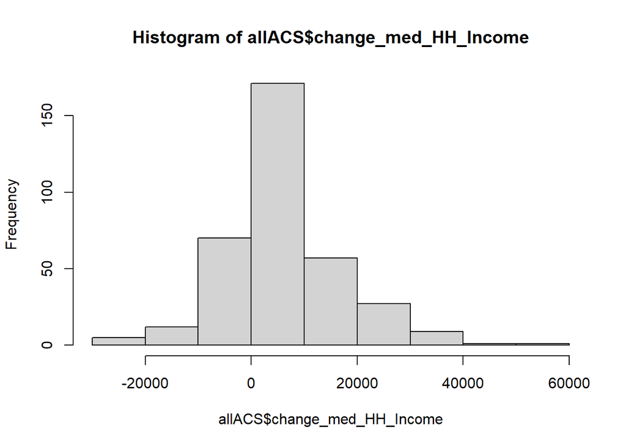

```r
hist(allACS$change_med_HH_Income)
```

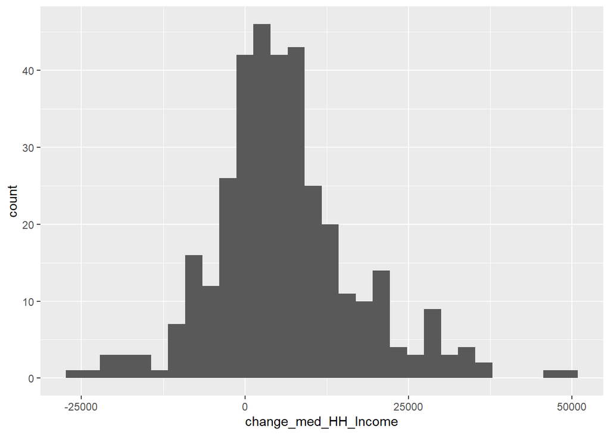

```r
ggplot(allACS) +
  geom_histogram(aes(change_med_HH_Income))
```

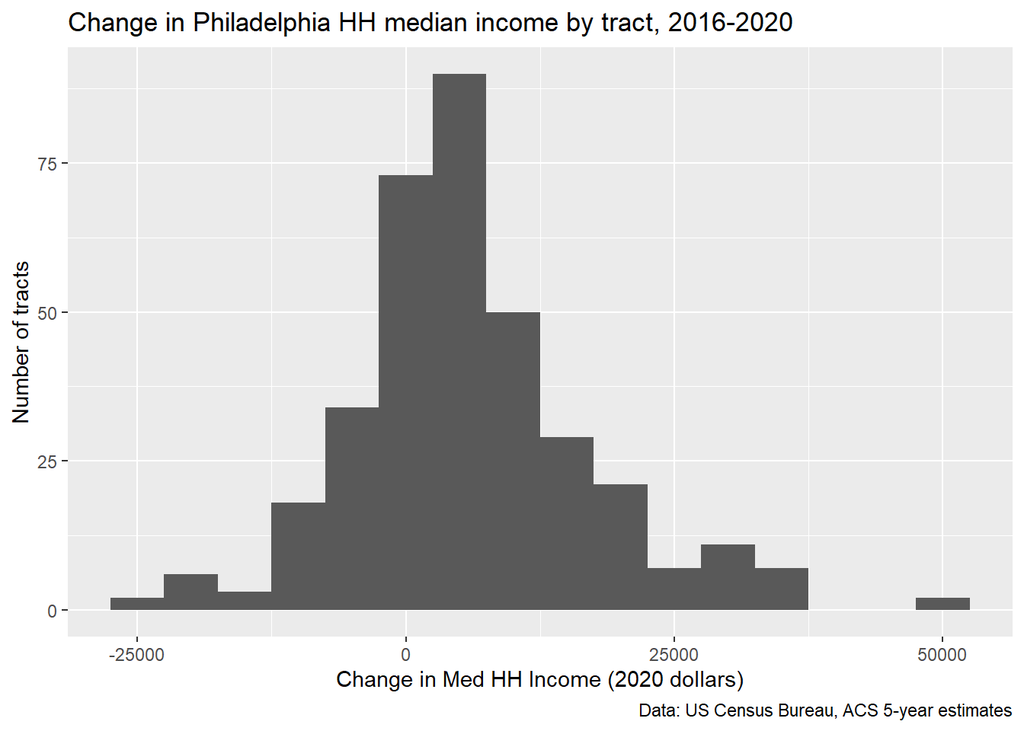

```r
ggplot(allACS)+
  geom_histogram(aes(change_med_HH_Income), binwidth = 5000)+
  labs(
    title = "Change in Philadelphia HH median income by tract, 2016-2020",
    caption = "Data: US Census Bureau, ACS 5-year estimates",
    x="Change in Med HH Income (2020 dollars)",
       y="Number of tracts")
```

#### Making a summary table

```r
summaryTable <- allACS %>%
  summarize(mean_change_HH_Income = mean(change_med_HH_Income, na.rm = TRUE),
            med_change_HH_Income = median(change_med_HH_Income, na.rm = TRUE))
```

### Comparing geographies

```r
myTracts <- c("42101023500",
              "42101023600",
              "42101023700",
              "42101025300",
              "42101025400",
              "42101025500",
              "42101025600",
              "42101038800")

allACS <- allACS %>%
  mutate(mtAiry = ifelse(GEOID %in% myTracts, "MT AIRY", "REST OF PHILADELPHIA"))
```

```r
summaryTable2 <- allACS %>%
  group_by(mtAiry) %>%
  summarize(mean_change_HH_Income = mean(change_med_HH_Income, na.rm = TRUE),
            med_change_HH_Income = median(change_med_HH_Income, na.rm = TRUE))
```

#### Graphic comparisons Using ggplot2

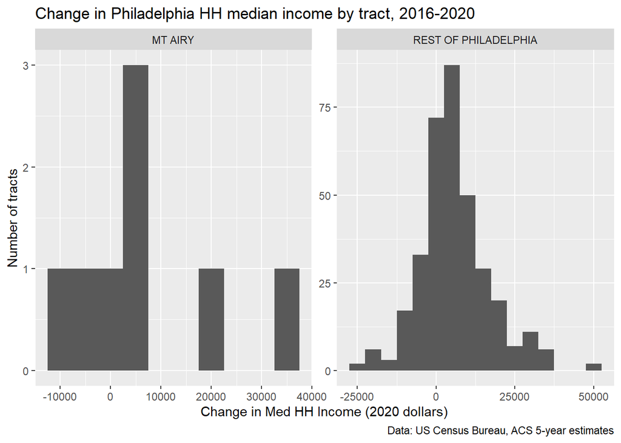

```r
ggplot(allACS)+
  geom_histogram(aes(change_med_HH_Income),
                 binwidth = 5000)+
  labs(
    title = "Change in Philadelphia HH median income by tract, 2016-2020",
    caption = "Data: US Census Bureau, ACS 5-year estimates",
    x="Change in Med HH Income (2020 dollars)",
       y="Number of tracts")+
  facet_wrap(~mtAiry, scales = "free")
```

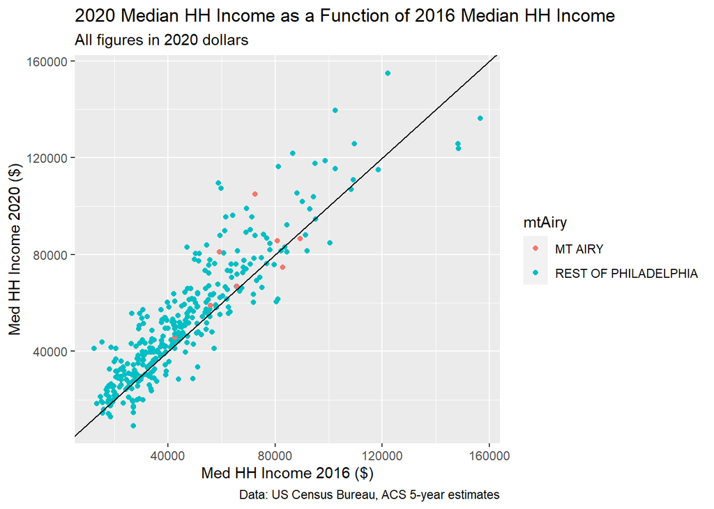

```r
ggplot(allACS)+
  geom_point(aes(x =med_HH_Income.2016 * 1.08,
                 y = med_HH_Income.2020,
                 color = mtAiry))+
  geom_abline(intercept = 0, slope = 1)+
  labs(
    title = "2020 Median HH Income as a Function of 2016 Median HH Income",
    subtitle = "All figures in 2020 dollars",
    caption = "Data: US Census Bureau, ACS 5-year estimates",
    x="Med HH Income 2016 ($)",
    y="Med HH Income 2020 ($)")
```

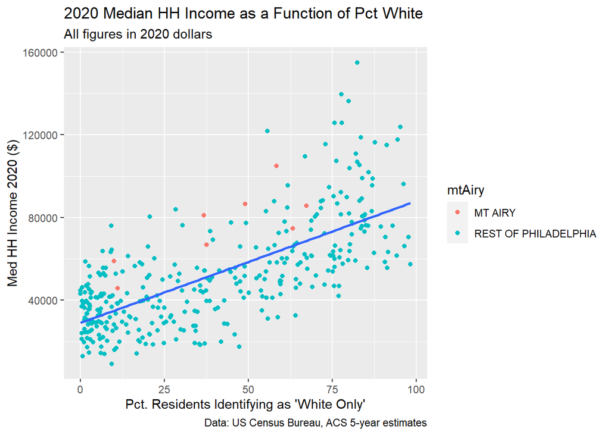

```r
ggplot(allACS)+
  geom_point(aes(x = 100* pctWhite.2020,
                 y = med_HH_Income.2020,
                 color = mtAiry))+
  geom_smooth(aes(x = 100* pctWhite.2020,
                  y = med_HH_Income.2020),
              method = "lm", se = FALSE)+
  labs(
    title = "2020 Median HH Income as a Function of Pct White",
    subtitle = "All figures in 2020 dollars",
    caption = "Data: US Census Bureau, ACS 5-year estimates",
    x="Pct. Residents Identifying as 'White Only'",
    y="Med HH Income 2020 ($)")
```

# Homework part

## Part.1 City-wide - number of vacant housing units per tract changing

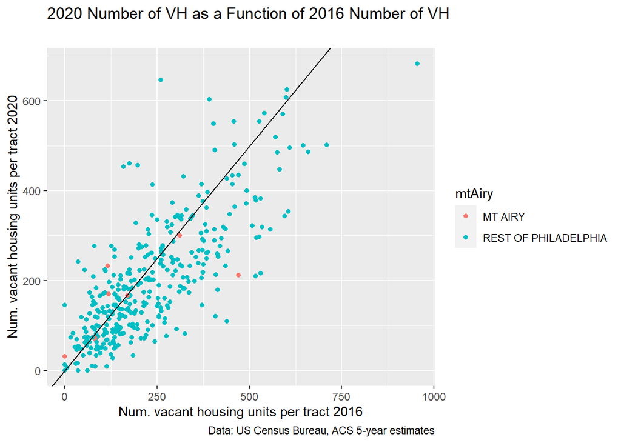

```r
ggplot(allACS)+
  geom_point(aes(x =total_vacant.2016,
                 y = total_vacant.2020,
                 color = mtAiry))+
  geom_abline(intercept = 0, slope = 1)+
  labs(
    title = "2020 Number of VH as a Function of 2016 Number of VH",
    subtitle = " ",
    caption = "Data: US Census Bureau, ACS 5-year estimates",
    x="Num. vacant housing units per tract 2016",
    y="Num. vacant housing units per tract 2020")
```

## Part.2 Number of vacant housing units in 2016 as a percentage of total housing units

```r
acsTractsPHL.2016.sf <- get_acs(geography = "tract",
                             year = 2016,
                             variables = acs_vars,
                             geometry = TRUE,
                             state = "PA",
                             county = "Philadelphia",
                             output = "wide") %>%
  dplyr::select (GEOID, NAME, all_of(acs_vars)) %>%
  rename (total_pop.2016 = B01001_001E,
          total_HU.2016 = B25002_001E,
          total_vacant.2016 = B25002_003E,
          med_HH_Income.2016 = B19013_001E,
          total_White.2016 = B02001_002E,
          total_GradDeg.2016 = B06009_006E) %>%
  mutate(pctvh.2016= total_vacant.2016/total_HU.2016) %>%
  mutate(mtAiry = ifelse(GEOID %in% myTracts, "MT AIRY", "REST OF PHILADELPHIA")) %>%
  st_as_sf(crs = 4326) # Turn shp into sf object and project as WGS84
```

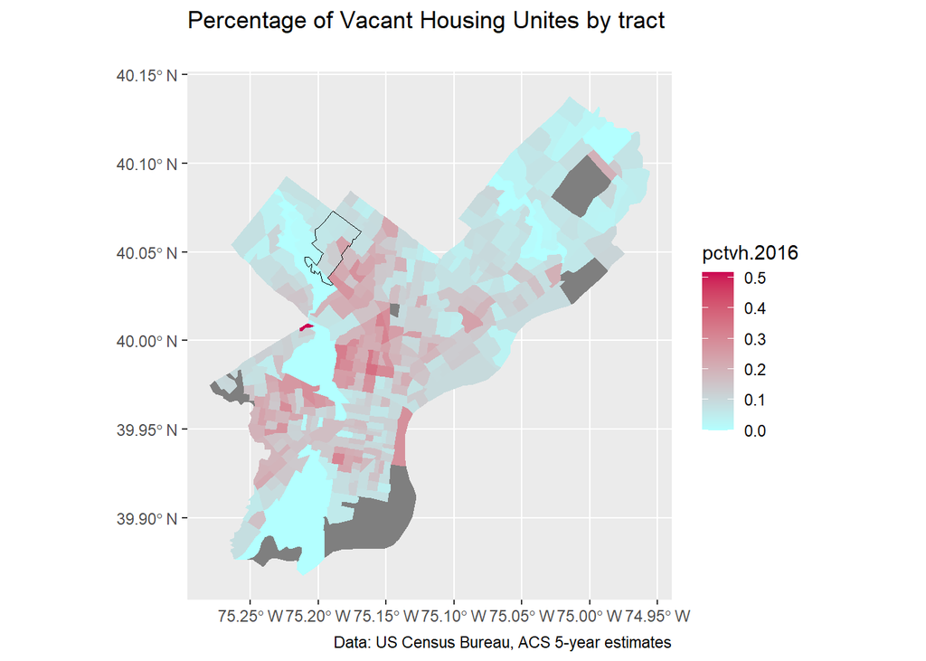

```r
ggplot()+
  geom_sf(data = acsTractsPHL.2016.sf, aes(fill = pctvh.2016),
          color = "transparent")+
  scale_fill_gradient(low = "#B3FFFF", high = "#CC0052") +
  geom_sf(data = acsTractsPHL.2016.sf %>%
            filter(mtAiry == "MT AIRY") %>%
            st_union(),
          color = "Black",
          fill = "transparent")+
  labs(
    title = "Percentage of Vacant Housing Unites by tract",
    subtitle = "",
    caption = "Data: US Census Bureau, ACS 5-year estimates")
```

Philadelphia has a large number of vacant buildings, especially near the center; but the problem is relatively less severe in Mt Airy.

## Part.3 A table showing a summary of mean number of vacant housing units per tract

```r
summaryTable3 <- allACS %>%
  group_by(mtAiry) %>%
  summarize(Average_VH_Per_Tract = mean(total_vacant.2020, na.rm = TRUE))
```

```r
summaryTable3%>%
  kbl(caption = "Mean. Vacant housing units per tract") %>%
  kable_classic("hover", full_width = F) %>%
  column_spec(2, color = spec_color(mtcars$mpg[6:9]))
```

Mean. Vacant housing units per tract

| mtAiry | Average_VH_Per_Tract |
| --- | --- |
| MT AIRY | 156.625 |
| REST OF PHILADELPHIA | 196.893 |

# Spatial Data and Tidycensus

Tidycensus can also provide us with a geometry for our data. The `sf` package handles shapefiles and interfaces well with `tidycensus` to allow us to analyze and map spatial data. Next lesson we will do some spatial analysis using these data.

Notice that there is a `geometry` column in our data frame now - it’s actually an `sf` object, which is just like a data frame except it has a column with drawing instructions that you can’t operate on or alter.

Notice we create a `geom_sf` which symbologizes our data and then another which is designed to represent the boundary of Mt. Airy.

In our next lesson, we will do more detailed cartography and spatial analysis using ggplot - using custom color palettes and more.

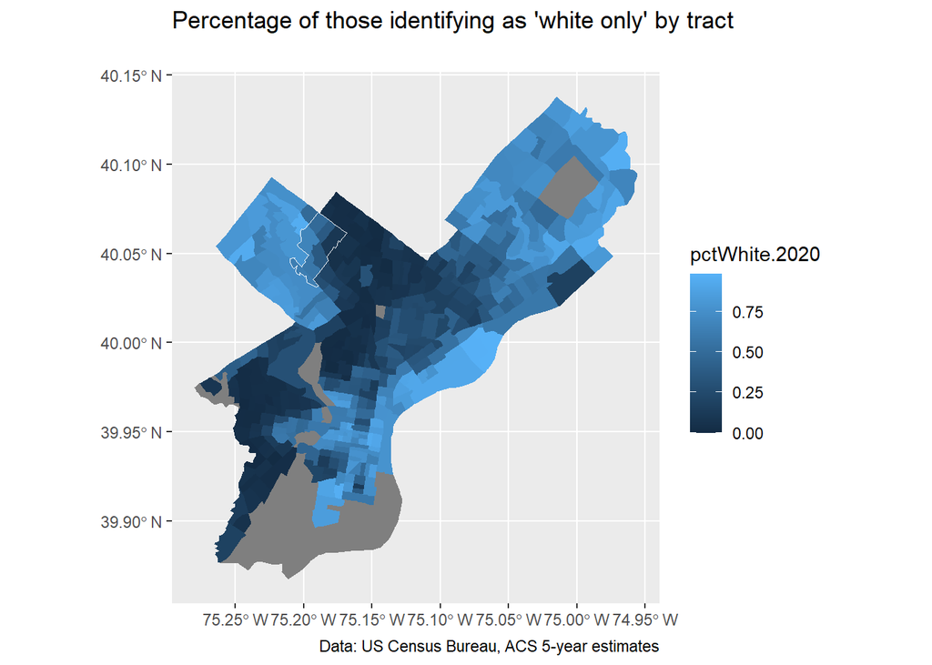

```r
ggplot()+
  geom_sf(data = acsTractsPHL.2020.sf, aes(fill = pctWhite.2020),
          color = "transparent")+
  geom_sf(data = acsTractsPHL.2020.sf %>%
            filter(mtAiry == "MT AIRY") %>%
            st_union(),
          color = "white",
          fill = "transparent")+
  labs(
    title = "Percentage of those identifying as 'white only' by tract",
    subtitle = "",
    caption = "Data: US Census Bureau, ACS 5-year estimates")
```

# Discussion

- How would you describe the income and demographic statistics and trends in Mt. Airy relative to those of Philadelphia as a whole?
- Do you have a particular hypothesis about “stories” about Mt. Airy based on a look at the data in a spatial format?
- What do you think about the similarities and differences within the neighborhood? How can you probe at those using these data?
- Can you think of any other ways to subdivide the data we looked at in class to glean more insights about Mt. Airy?